# Building Statistical Summaries with R-Part 1

#### Name: Suman Kumar

#### Purpose:

#### Status: Incomplete

#### To Add conclusion to the analysis

## Using R with Jupyter lab*Buliding Statistical Summaries*

```r
library(ggplot2,dplyr)
```

```r
df=read.csv("B:/R_Jobs/R_task3/laptops.csv", stringsAsFactors = F)
head(df,3)
```

| X | Company | Product | TypeName | Inches | ScreenResolution | Cpu | Ram | Memory | Gpu | OpSys | Weight | Price_euros |
| --- | --- | --- | --- | --- | --- | --- | --- | --- | --- | --- | --- | --- |
| 1 | Apple | MacBook Pro | Ultrabook | 13.3 | IPS Panel Retina Display 2560x1600 | Intel Core i5 2.3GHz | 8GB | 128GB SSD | Intel Iris Plus Graphics 640 | macOS | 1.37kg | 1339.69 |
| 2 | Apple | Macbook Air | Ultrabook | 13.3 | 1440x900 | Intel Core i5 1.8GHz | 8GB | 128GB Flash Storage | Intel HD Graphics 6000 | macOS | 1.34kg | 898.94 |
| 3 | HP | 250 G6 | Notebook | 15.6 | Full HD 1920x1080 | Intel Core i5 7200U 2.5GHz | 8GB | 256GB SSD | Intel HD Graphics 620 | No OS | 1.86kg | 575.00 |

```r
dim(df)
```

1. 1303

2. 13

```r
# colSums(is.na(df)) # Is a cleaned Data set
```

```r
summary(df$Price_euros)
```

```
   Min. 1st Qu.  Median    Mean 3rd Qu.    Max.
    174     599     977    1124    1488    6099
```

```r
options(repr.plot.width=6, repr.plot.height=4)
```

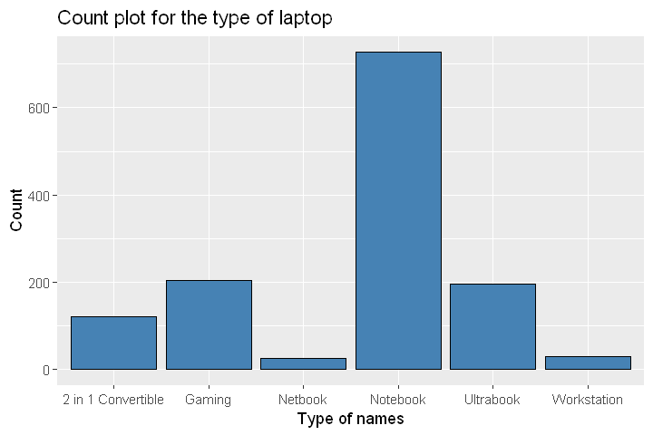

```r
ggplot(data=df,aes(factor(x=TypeName)))+
geom_bar(col="black",fill="steelblue")+
ggtitle("Count plot for the type of laptop")+
xlab("Type of names")+
ylab("Count")
```

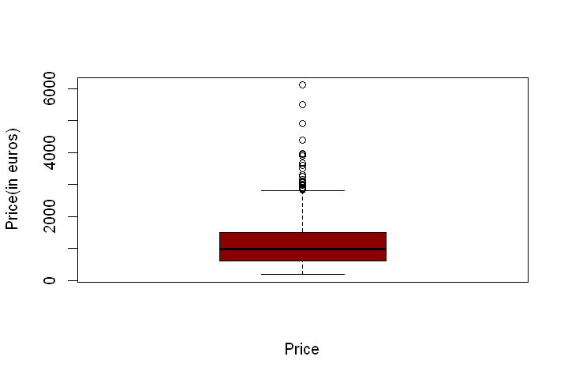

```r
price_boxplot<-boxplot(df$Price_euros,col="darkred",xlab='Price',ylab='Price(in euros)')
```

```r
laptop_price_processed<-price_boxplot$out
```

```r
laptop_price_processed<-df[-which(df$Price_euros %in% price_boxplot$out),]#check out the uses of this statement
```

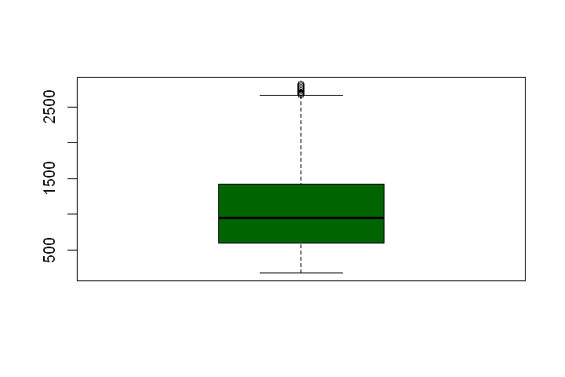

```r
boxplot(laptop_price_processed$Price_euros,col="darkgreen") #eliminates most of the outliers
```

#### Shapiro Test to see if the data is normally distributed or not...

```r
shapiro.test(laptop_price_processed$Price_euros)
```

```
	Shapiro-Wilk normality test

data:  laptop_price_processed$Price_euros
W = 0.94014, p-value < 2.2e-16
```

The test statistics of .94 and p-value of less than 5% or 1% whatever the benchmark. Q) This suggest we have to accept the alternative hypothesis and reject the null hypotheis? Ans- Ho- In shapiro's test, null hypotheis is the given data is normal... Q) Two tailed test... If p value less than threshold we reject the null hypothesis and vice-versa Type 1 and Type 2 test needs to be considered

The standard normal (or Z-distribution), is the most common normal distribution, with a mean of 0 and standard deviation of 1. The t-distribution can be thought of as a cousin of the standard normal distribution — it looks similar in that it’s centered at zero and has a basic bell-shape, but it’s shorter and flatter around the center than the Z-distribution.

Its standard deviation is proportionally larger compared to the Z, which is why you see the fatter tails on each side.

```r
# ls("package:ggplot2")
# library(tidyverse)
# ggqqplot(laptop_price_processed$Price_euros, ggtheme=theme_minimal())
ggqqplot(laptop_price_processed,Price_euros) # To obtain ans about which distribution matches our data
```

[output not shown]

1. The t-distribution can be thought of as a cousin of the standard normal distribution — it looks similar in that it’s centered at zero and has a basic bell-shape, but it’s shorter and flatter around the center than the Z-distribution. Its standard deviation is proportionally larger compared to the Z, which is why you see the fatter tails on each side.

```r
test<-function(mean,std,mu,n){
    test_statistics<-(mean-mu)/(std/sqrt(n))
    if (n>30){
        p_value<-2*pnorm(-abs(test_statistics))
        return(cat('z-test=',test_statistics,'\np_value', p_value))
    }
    else{
        p_value<-2*pt(test_statistic,df=n-1,lower="FALSE")
        return(cat('t-test=',test_statistics,'\np_value', p_value))

    }
}
```

```r
mu=1000
mean_price<-mean(laptop_price_processed$Price_euros)
std_price<-sd(laptop_price_processed$Price_euros)
n_price<-length(laptop_price_processed$Price_euros)
```

```r
test(mean_price,mu,std_price, n_price)
#The data below doesnot seem to be good match
```

```
z-test= 16.90177
p_value 4.366158e-64
```

```r
install.packages(c("pastecs","TeachingDemos"))
```

```r
library("pastecs")
library("TeachingDemos")
```

```r
price_ztest<-z.test(laptop_price_processed$Price_euros,mu=mu,stdev=std_price)
```

```r
price_ztest
```

```
	One Sample z-test

data:  laptop_price_processed$Price_euros
z = 4.1946, n = 1274.000, Std. Dev. = 596.579, Std. Dev. of the sample
mean = 16.714, p-value = 2.734e-05
alternative hypothesis: true mean is not equal to 1000
95 percent confidence interval:
 1037.350 1102.868
sample estimates:
mean of laptop_price_processed$Price_euros
                                  1070.109
```

```r
price_ztest$method # which method used
price_ztest$data.name # what coloumn was used
price_ztest$statistic # ?
price_ztest$p.value # The p- value
price_ztest$conf.int
# the 95% confidence interval [The meaning of 95 % confidence interval mean
# that you could be 95% sure that mean is with in the given range
#...with large sample the 95% range intervel tends to shrink because we get more sure about where our mean is]

price_ztest$estimate #the mean price estimate
```

'One Sample z-test'

'laptop_price_processed$Price_euros'

**z:** 4.19459104275226

2.73364339397459e-05

1. 1037.34979716464

2. 1102.86789514305

**mean of laptop_price_processed$Price_euros:** 1070.10884615385

```r
price_t_test<-t.test(x=laptop_price_processed$Price_euros,y=NULL,mu=1000)
```

```r
price_t_test
```

```
	One Sample t-test

data:  laptop_price_processed$Price_euros
t = 4.1946, df = 1273, p-value = 2.923e-05
alternative hypothesis: true mean is not equal to 1000
95 percent confidence interval:
 1037.319 1102.899
sample estimates:
mean of x
 1070.109
```

```r
R.home()
```

'C:/Users/TOSHABA/Anaconda3/lib/R'

Learnings _not directly related to the problem statement

```r
version[['version.string']]
#
```

'R version 3.6.1 (2019-07-05)'